# Text Classicaition

**CS 4395 - Intro to NLP**

**Dr. Karen Mazidi**

**Prepare by Leo Nguyen - ldn190002**

### Instruction 1

```
- Find a text classification data set that interests you.
- Divide into train/test
- Create a graph showing the distribution of the target classes.
- Describe the data set and what the model should be able to predict.
```

Import all require modules an packages

```python
# some necessary packages
import tensorflow as tf
from tensorflow import keras
from tensorflow.keras.preprocessing.text import Tokenizer
from tensorflow.keras import datasets, layers, models, preprocessing

from sklearn.preprocessing import LabelEncoder
import pickle
import numpy as np
import pandas as pd
import seaborn as sb
from fast_ml.model_development import train_valid_test_split

# set seed for reproducibility
np.random.seed(1234)
```

Read the dataset. Only read the: title, text and lable. Ignore the index column in the cvs file

```python
df = pd.read_csv('WELFake_Dataset.csv', header=0, usecols=[1,2,3], encoding='latin-1')
print('rows and columns:', df.shape)
print(df.head())
```

```
rows and columns: (72134, 3)
                                               title  \
0  LAW ENFORCEMENT ON HIGH ALERT Following Threat...
1                                                NaN
2  UNBELIEVABLE! OBAMAâS ATTORNEY GENERAL SAYS ...
3  Bobby Jindal, raised Hindu, uses story of Chri...
4  SATAN 2: Russia unvelis an image of its terrif...

                                                text  label
0  No comment is expected from Barack Obama Membe...      1
1     Did they post their votes for Hillary already?      1
2   Now, most of the demonstrators gathered last ...      1
3  A dozen politically active pastors came here f...      0
4  The RS-28 Sarmat missile, dubbed Satan 2, will...      1
```

Check the NAs value in entire dataset. Show counts for each column

```python
df.isnull().sum()
```

```
title    558
text      39
label      0
dtype: int64
```

**Do some clean up on dataset**

Delete rows with NAs. And output the new dimension

```python
df = df.dropna()
print('\nDimensions of data frame:', df.shape)
```

```
Dimensions of data frame: (71537, 3)
```

**Divide into train/test**

```python
# split df into train and test
i = np.random.rand(len(df)) < 0.8
train = df[i]
test = df[~i]
print("train data size: ", train.shape)
print("test data size: ", test.shape)
```

```
train data size:  (57199, 3)
test data size:  (14338, 3)
```

**Graph showing the distribution of the target classes for entire dataset**

The target class is the **label** column which classify which news is real, which is fake.

Based on the graph, we can see that, we have almost equal amount of fake news and real news on the dataset.

Label (0 = fake and 1 = real).

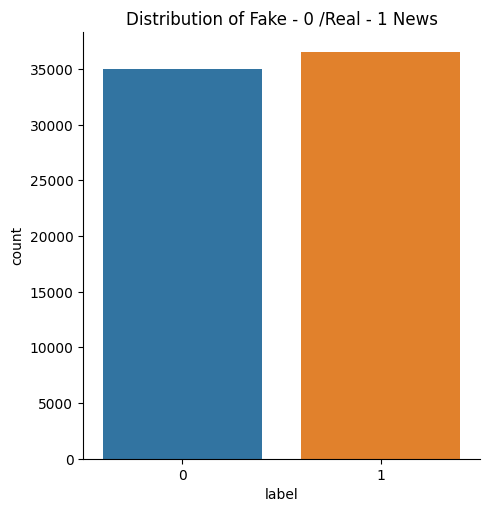

```python
sb.catplot(data=df, x="label", kind='count').set(title='Distribution of Fake - 0 /Real - 1 News')
```

**Describe the data set and what the model should be able to predict.**

[output not shown]

### Intruction 2 - Sequential Model

```
- Create a sequential model
- Evaluate on the test data
```

```python
df.head()
```

|  | title | text | label |
| --- | --- | --- | --- |
| 0 | LAW ENFORCEMENT ON HIGH ALERT Following Threat... | No comment is expected from Barack Obama Membe... | 1 |
| 2 | UNBELIEVABLE! OBAMAâS ATTORNEY GENERAL SAYS ... | Now, most of the demonstrators gathered last ... | 1 |
| 3 | Bobby Jindal, raised Hindu, uses story of Chri... | A dozen politically active pastors came here f... | 0 |
| 4 | SATAN 2: Russia unvelis an image of its terrif... | The RS-28 Sarmat missile, dubbed Satan 2, will... | 1 |
| 5 | About Time! Christian Group Sues Amazon and SP... | All we can say on this one is it s about time ... | 1 |

**Create a sequential model**

Prepare the data before building model

```python
# set up X and Y
num_labels = 2
vocab_size = 25000
batch_size = 100

# fit the tokenizer on the training data
tokenizer = Tokenizer(num_words=vocab_size)
tokenizer.fit_on_texts(train.text) # Only use text column as the predictor for the models

x_train = tokenizer.texts_to_matrix(train.text, mode='tfidf')
x_test = tokenizer.texts_to_matrix(test.text, mode='tfidf')

encoder = LabelEncoder()
encoder.fit(train.label)
y_train = encoder.transform(train.label)
y_test = encoder.transform(test.label)

# check shape
print("train shapes:", x_train.shape, y_train.shape)
print("test shapes:", x_test.shape, y_test.shape)
print("test first five labels:", y_test[:5])
```

```
train shapes: (57199, 25000) (57199,)
test shapes: (14338, 25000) (14338,)
test first five labels: [1 1 1 1 1]
```

Build the model

```python
# fit model
model1 = models.Sequential()
model1.add(layers.Dense(32, input_dim=vocab_size, kernel_initializer='normal', activation='relu'))
model1.add(layers.Dense(1, kernel_initializer='normal', activation='sigmoid'))

# compile
model1.compile(loss='binary_crossentropy',
              optimizer='adam',
              metrics=['accuracy'])

# train
history = model1.fit(x_train, y_train,
                    batch_size=batch_size,
                    epochs=30,
                    verbose=1,
                    validation_split=0.1)
```

```python
# Show model summary
model1.summary()
```

```
Model: "sequential"
_________________________________________________________________
 Layer (type)                Output Shape              Param #
=================================================================
 dense (Dense)               (None, 32)                800032

 dense_1 (Dense)             (None, 1)                 33

=================================================================
Total params: 800,065
Trainable params: 800,065
Non-trainable params: 0
_________________________________________________________________
```

**Evaluation**

Use model to predict the target on test data

```python
# get predictions so we can calculate more metrics
pred = model1.predict(x_test)
pred_labels = [1 if p>0.5 else 0 for p in pred]
pred[:10]
```

```
array([[1.0000000e+00],
       [1.0000000e+00],
       [1.0000000e+00],
       [1.0000000e+00],
       [9.9999946e-01],
       [4.2885760e-24],
       [1.0620265e-26],
       [1.0000000e+00],
       [1.0000000e+00],
       [1.0000000e+00]], dtype=float32)
```

Evaluate and calculate the metrics

```python
from sklearn.metrics import accuracy_score, precision_score, recall_score, f1_score
print('accuracy score: ', accuracy_score(y_test, pred_labels))
print('precision score: ', precision_score(y_test, pred_labels))
print('recall score: ', recall_score(y_test, pred_labels))
print('f1 score: ', f1_score(y_test, pred_labels))
```

```
accuracy score:  0.9745431719905148
precision score:  0.9727137646899905
recall score:  0.9778652906029331
f1 score:  0.9752827249949211
```

### Instruction 3 - Sequential Model with RNN, CNN Architecture

Try different architecture like RNN, CNN, etc and evaluate on the test data

### RNN Architecture

Prepare the data before building model

```python
# Try different set up for X and Y
max_features = 10000
maxlen = 500
batch_size = 32


# pad the data to maxlen
train_data = preprocessing.sequence.pad_sequences(x_train, maxlen=maxlen)
test_data = preprocessing.sequence.pad_sequences(x_test, maxlen=maxlen)
```

Build model with RNN Architecture

```python
# build a Sequential model with Embedding and SimpleRNN layers

model2 = models.Sequential()
model2.add(layers.Embedding(max_features, 32))
model2.add(layers.SimpleRNN(32))
model2.add(layers.Dense(1, activation='sigmoid'))

# compile
model2.compile(optimizer='rmsprop',
              loss='binary_crossentropy',
              metrics=['accuracy'])

# train
history = model2.fit(train_data,
                    y_train,
                    epochs=10,
                    batch_size=128,
                    validation_split=0.2)
```

```python
# Show model summary
model2.summary()
```

```
Model: "sequential_1"
_________________________________________________________________
 Layer (type)                Output Shape              Param #
=================================================================
 embedding (Embedding)       (None, None, 32)          320000

 simple_rnn (SimpleRNN)      (None, 32)                2080

 dense_2 (Dense)             (None, 1)                 33

=================================================================
Total params: 322,113
Trainable params: 322,113
Non-trainable params: 0
_________________________________________________________________
```

**Evaluation of RNN**

Evaluate and calculate the metrics

```python
from sklearn.metrics import classification_report

# get predictions so we can calculate more metrics
pred = model2.predict(test_data)
pred_labels = [1 if p>0.5 else 0 for p in pred]
print(classification_report(y_test, pred_labels))
```

```
              precision    recall  f1-score   support

           0       0.52      0.02      0.03      6974
           1       0.51      0.99      0.68      7364

    accuracy                           0.51     14338
   macro avg       0.52      0.50      0.35     14338
weighted avg       0.52      0.51      0.36     14338
```

### CNN Architecture

Build model with CNN Architecture

```python
# build a Sequential model 1D convnet

model3 = models.Sequential()
model3.add(layers.Embedding(max_features, 128, input_length=maxlen))
model3.add(layers.Conv1D(32, 7, activation='relu'))
model3.add(layers.MaxPooling1D(5))
model3.add(layers.Conv1D(32, 7, activation='relu'))
model3.add(layers.GlobalMaxPooling1D())
model3.add(layers.Dense(1))

# compile
model3.compile(optimizer=tf.keras.optimizers.RMSprop(learning_rate=1e-4),  # set learning rate
              loss='binary_crossentropy',
              metrics=['accuracy'])

# train
history = model3.fit(train_data,
                    y_train,
                    epochs=10,
                    batch_size=128,
                    validation_split=0.2)
```

```python
# Show model summary
model3.summary()
```

```
Model: "sequential_2"
_________________________________________________________________
 Layer (type)                Output Shape              Param #
=================================================================
 embedding_1 (Embedding)     (None, 500, 128)          1280000

 conv1d (Conv1D)             (None, 494, 32)           28704

 max_pooling1d (MaxPooling1D  (None, 98, 32)           0
 )

 conv1d_1 (Conv1D)           (None, 92, 32)            7200

 global_max_pooling1d (Globa  (None, 32)               0
 lMaxPooling1D)

 dense_3 (Dense)             (None, 1)                 33

=================================================================
Total params: 1,315,937
Trainable params: 1,315,937
Non-trainable params: 0
_________________________________________________________________
```

**Evaluation of CNN**

Evaluate and calculate the metrics

```python
from sklearn.metrics import classification_report

# get predictions so we can calculate more metrics
pred = model3.predict(test_data)
pred_labels = [1 if p>0.5 else 0 for p in pred]
print(classification_report(y_test, pred_labels))
```

```
              precision    recall  f1-score   support

           0       0.49      0.97      0.65      6974
           1       0.54      0.04      0.07      7364

    accuracy                           0.49     14338
   macro avg       0.51      0.50      0.36     14338
weighted avg       0.51      0.49      0.35     14338
```

### Instruction 4 - Model with Embedded Layer Approaches

```
- Try different embedding approaches and evaluate on the test data
```

Preprocessing data before building and feeding into model

```python
df.head()
```

|  | title | text | label |
| --- | --- | --- | --- |
| 0 | LAW ENFORCEMENT ON HIGH ALERT Following Threat... | No comment is expected from Barack Obama Membe... | 1 |
| 2 | UNBELIEVABLE! OBAMAâS ATTORNEY GENERAL SAYS ... | Now, most of the demonstrators gathered last ... | 1 |
| 3 | Bobby Jindal, raised Hindu, uses story of Chri... | A dozen politically active pastors came here f... | 0 |
| 4 | SATAN 2: Russia unvelis an image of its terrif... | The RS-28 Sarmat missile, dubbed Satan 2, will... | 1 |
| 5 | About Time! Christian Group Sues Amazon and SP... | All we can say on this one is it s about time ... | 1 |

```python
# Removing the title from dataset
df1 = df.drop(columns=['title'])
df1.head()
```

|  | text | label |
| --- | --- | --- |
| 0 | No comment is expected from Barack Obama Membe... | 1 |
| 2 | Now, most of the demonstrators gathered last ... | 1 |
| 3 | A dozen politically active pastors came here f... | 0 |
| 4 | The RS-28 Sarmat missile, dubbed Satan 2, will... | 1 |
| 5 | All we can say on this one is it s about time ... | 1 |

The original size of dataset is too big for my computer to process.

Try with google colab. It is still not be able to process unless i upgrage to Pro Version

==> Reduce the dataset to 1/3 of its original. So it could be process with my own computer

```python
df1 = df1.sample(frac=0.3)  # Reduce dataset to 1/3 of it original size
```

Encoding and decoding the string data so it could be vectorizer later

```python
df1['text'] = df1['text'].apply(lambda x: x.encode("latin-1").decode("ascii","ignore"))
```

### Split into train/validation/test using fast_ml package

```python
train_samples, train_labels, val_samples, val_labels, test_samples, test_labels = train_valid_test_split(df1, target = 'label',
                                                                            train_size=0.8, valid_size=0.1, test_size=0.1)

print('Labels sizes of train, validation, test:', len(train_labels), len(val_labels), len(test_labels))
print('Samples sizes of train, validation, test:', len(train_samples), len(val_samples), len(test_samples))
```

```
Labels sizes of train, validation, test: 17168 2146 2147
Samples sizes of train, validation, test: 17168 2146 2147
```

```python
train_samples.shape
```

```
(17168, 1)
```

```python
train_labels.shape
```

```
(17168,)
```

**Set up the vectorizer**

```
- Use Keras's TextVectorization() function to vectorize the data, using only the top 20K words. Each sample will be truncated or padded to a length of 200
```

```python
from tensorflow.keras.layers.experimental.preprocessing import TextVectorization

vectorizer = TextVectorization(max_tokens=20000, output_sequence_length=200)
text_ds = tf.data.Dataset.from_tensor_slices(train_samples).batch(128)
vectorizer.adapt(text_ds)
```

```python
# create a word index dictionary in which words map to indices
voc = vectorizer.get_vocabulary()
word_index = dict(zip(voc, range(len(voc))))
len(word_index)
```

```
20000
```

### Building the model:

```
- The model will included:

            - Several layers of Conv1D followed by pooling.
            - Ending in a softmax classification layer.
            - Instead of the usual Keras syntax, this example uses syntax from the Functional API:
```

**Set up the embedding layer**

```python
EMBEDDING_DIM = 128
MAX_SEQUENCE_LENGTH = 200

embedding_layer = layers.Embedding(len(word_index) + 1,
                            EMBEDDING_DIM,
                            input_length=MAX_SEQUENCE_LENGTH)
```

**Building model using syntax from the Functional API**

```python
# add more layers

int_sequences_input = keras.Input(shape=(None,), dtype="int64")
embedded_sequences = embedding_layer(int_sequences_input)
x = layers.Conv1D(128, 5, activation="relu")(embedded_sequences)
x = layers.MaxPooling1D(5)(x)
x = layers.Conv1D(128, 5, activation="relu")(x)
x = layers.MaxPooling1D(5)(x)
x = layers.Conv1D(128, 5, activation="relu")(x)
x = layers.GlobalMaxPooling1D()(x)
x = layers.Dense(128, activation="relu")(x)
x = layers.Dropout(0.5)(x)
preds = layers.Dense(1, activation="softmax")(x)
model4 = keras.Model(int_sequences_input, preds)
model4.summary()
```

```
Model: "model"
_________________________________________________________________
 Layer (type)                Output Shape              Param #
=================================================================
 input_1 (InputLayer)        [(None, None)]            0

 embedding_2 (Embedding)     (None, None, 128)         2560128

 conv1d_2 (Conv1D)           (None, None, 128)         82048

 max_pooling1d_1 (MaxPooling  (None, None, 128)        0
 1D)

 conv1d_3 (Conv1D)           (None, None, 128)         82048

 max_pooling1d_2 (MaxPooling  (None, None, 128)        0
 1D)

 conv1d_4 (Conv1D)           (None, None, 128)         82048

 global_max_pooling1d_1 (Glo  (None, 128)              0
 balMaxPooling1D)

 dense_4 (Dense)             (None, 128)               16512

 dropout (Dropout)           (None, 128)               0

 dense_5 (Dense)             (None, 1)                 129

=================================================================
Total params: 2,822,913
Trainable params: 2,822,913
Non-trainable params: 0
_________________________________________________________________
```

**Vectorize train and validation sets**

Converting the samples/predictor of train and validation to list of string before vectorizer

```python
type(val_samples)
```

```
pandas.core.frame.DataFrame
```

```python
val_samples.head()
```

|  | text |
| --- | --- |
| 4702 | If a grand jury indicts Donald Trump, one Fox ... |
| 30075 | Share on Facebook Share on Twitter This is som... |
| 7079 | One way or another, she s going to have to fa... |
| 43755 | WASHINGTON (Reuters) - The U.S. Supreme Court ... |
| 11634 | Mises.org October 28, 2016 \nA recent op-ed pi... |

Converting the train and validation dataframe to list of string so it can be convert to numpy array then vecterizor

```python
x_train = train_samples.text.values.tolist()
x_val = val_samples.text.values.tolist()
```

Vectorizer the data to right-pad the samples

```python
x_train = vectorizer(np.array([[s] for s in x_train])).numpy()
x_val = vectorizer(np.array([[s] for s in x_val])).numpy()

y_train = np.array(train_labels)
y_val = np.array(val_labels)
```

```python
print('Size of train sample after padding:', len(x_train))
print('Size of train label after padding:', len(y_train))
```

```
Size of train sample after padding: 17168
Size of train label after padding: 17168
```

```python
print('Size of val sample after padding:', len(x_val))
print('Size of val label after padding:', len(y_val))
```

```
Size of val sample after padding: 2146
Size of val label after padding: 2146
```

**Train the embedded layer model**

```
- Binary_crossentropy is used because the final layer is have only either 0 or 1.
```

```python
# compile
model4.compile(loss="binary_crossentropy",
              optimizer="rmsprop",
              metrics=["acc"])

# train
model4.fit(x_train, y_train,
          batch_size=128,
          epochs=20,
          validation_data=(x_val, y_val))
```

```
<keras.callbacks.History at 0x19d1236ebf0>
```

**Evaluation using Embedded_layer approach**

Converting test_sample dataframe to list of string

Vectorizer the data to right-pad the samples

```python
test_x = test_samples.text.values.tolist()
test_x = vectorizer(np.array([[s] for s in test_x])).numpy()
```

Evaluate and calculate the metrics

```python
from sklearn.metrics import classification_report

preds = model4.predict(test_x)
pred_labels = [np.argmax(p) for p in preds]
print(classification_report(test_labels, pred_labels))
```

```
              precision    recall  f1-score   support

           0       0.49      1.00      0.65      1045
           1       0.00      0.00      0.00      1102

    accuracy                           0.49      2147
   macro avg       0.24      0.50      0.33      2147
weighted avg       0.24      0.49      0.32      2147
```

### Instruction 4

```
- Analysis of the performance of various approaches
```

[output not shown]